# Materiales adicionales

Logo de R

Índice general del curso

Acá encontrás lecturas abiertas y ejemplos para practicar después de cada lección. Los ejemplos incluyen sus datos. Las citas a *Learning R* indican el capítulo donde se presenta la idea que usamos. [Datos y código del autor](https://github.com/richierocks/learningr).

## Lección 1 · Objetos, tipos y valores faltantes

¿Qué pasa con el promedio si falta un tiempo de viaje? Fijate en la segunda posición y compará el número de tiempos conocidos con el total de posiciones. El ejemplo retoma la detección de datos faltantes de *Learning R*. [Valores faltantes](https://r4ds.hadley.nz/missing-values.html) · *Learning R* (Cotton, 2013, cap. 2) · [Tipos de objetos](https://stat.ethz.ch/R-manual/R-devel/library/base/html/typeof.html) · *Learning R* (Cotton, 2013, cap. 3).

```r
tiempos <- c(20, NA, 35, 29)
typeof(tiempos)
```

```
## [1] "double"
```

```r
is.na(tiempos)
```

```
## [1] FALSE  TRUE FALSE FALSE
```

```r
sum(!is.na(tiempos))
```

```
## [1] 3
```

```r
mean(tiempos, na.rm = TRUE)
```

```
## [1] 28
```

Para ampliar, revisá cómo un proyecto organiza los scripts y archivos de datos. [R for Data Science, Scripts and Projects](https://r4ds.hadley.nz/workflow-scripts.html).

## Lección 2 · Listas, matrices y data frames

Pensá en una soda que registra sus ventas por día y producto. En el ejemplo usamos una matriz para las cantidades y una lista para guardar la matriz junto con el nombre de la sede. Compará qué devuelve `[]` con lo que devuelve `[[]]` al pedir un elemento de la lista. [Crear matrices](https://stat.ethz.ch/R-manual/R-devel/library/base/html/matrix.html) · *Learning R* (Cotton, 2013, cap. 4) · [Listas y data frames](https://cran.r-project.org/doc/manuals/r-release/R-intro.html#Lists-and-data-frames) · *Learning R* (Cotton, 2013, cap. 5).

```r
cantidades <- matrix(c(4, 8, 6, 5), nrow = 2, byrow = TRUE,
                     dimnames = list(c("lunes", "martes"), c("cafe", "pan")))
cantidades["martes", "pan"]
```

```
## [1] 5
```

```r
ficha <- list(sede = "Cartago", cantidades = cantidades)
ficha["cantidades"]
```

```
## $cantidades
##        cafe pan
## lunes     4   8
## martes    6   5
```

```r
ficha[["cantidades"]]
```

```
##        cafe pan
## lunes     4   8
## martes    6   5
```

```r
ventas <- data.frame(producto = c("Café", "Pan", "Té"), unidades = c(4, 8, 2))
ventas[ventas$unidades >= 4, "producto"]
```

```
## [1] "Café" "Pan"
```

## Lección 3 · Leer, limpiar, transformar y guardar

En el capítulo 12, el ejercicio 12-1 usa un CSV llamado `hafu.csv`. En el capítulo 13, Cotton calcula cuánto duró cada reinado a partir de las columnas de inicio y fin. Aplicá esas dos ideas a un CSV pequeño de préstamos. El ejemplo crea los archivos en una carpeta temporal, importa los datos, calcula una columna con `mutate()`, guarda un resumen y lo vuelve a leer. [Importar datos](https://r4ds.hadley.nz/data-import.html) · *Learning R* (Cotton, 2013, cap. 12) · [Transformar datos con dplyr](https://r4ds.hadley.nz/data-transform.html) · *Learning R* (Cotton, 2013, cap. 13).

```r
library(readr)
library(dplyr)
entrada <- tempfile(fileext = ".csv")
salida <- tempfile(fileext = ".csv")
writeLines(c("sede,inicio,devolucion", "Cartago,2,8", "Cartago,3,NA",
             "Heredia,5,9"), entrada)
prestamos <- read_csv(entrada, show_col_types = FALSE)
resumen <- prestamos |>
  mutate(dias = devolucion - inicio) |>
  group_by(sede) |>
  summarise(prestamos = n(), faltantes = sum(is.na(dias)),
            promedio_dias = mean(dias, na.rm = TRUE), .groups = "drop")
write_csv(resumen, salida)
read_csv(salida, show_col_types = FALSE)
```

```
## # A tibble: 2 x 4
##   sede    prestamos faltantes promedio_dias
##   <chr>       <dbl>     <dbl>         <dbl>
## 1 Cartago         2         1             6
## 2 Heredia         1         0             4
```

Para ampliar, consultá cómo `dplyr` agrega columnas y resume por grupo, y cómo `readr` escribe archivos. [R for Data Science, Data Transformation](https://r4ds.hadley.nz/data-transform.html) · [Documentación de write_csv()](https://readr.tidyverse.org/reference/write_delim.html).

## Lección 4 · Texto, expresiones regulares y ciclos

Un pedido puede venir con espacios o con letras en minúscula. En este ejemplo vas a limpiar los códigos, revisar su formato y mostrar el resultado de cada uno con un ciclo. Primero buscá coincidencias en el vector completo. Luego seguí el ciclo para ver cada código con su resultado. [Limpiar y buscar texto](https://r4ds.hadley.nz/strings.html) · *Learning R* (Cotton, 2013, cap. 13) · [Ciclos for](https://stat.ethz.ch/R-manual/R-devel/library/base/html/Control.html) · *Learning R* (Cotton, 2013, cap. 8).

```r
codigos <- c(" ped-017 ", "PED-21", "XPED-003", "PED-080")
codigos_limpios <- stringr::str_to_upper(stringr::str_squish(codigos))
patron <- "^PED-[0-9]{3}$"
validos <- stringr::str_detect(codigos_limpios, patron)
for (i in seq_along(codigos_limpios)) {
  print(paste(codigos_limpios[i], validos[i]))
}
```

```
## [1] "PED-017 TRUE"
## [1] "PED-21 FALSE"
## [1] "XPED-003 FALSE"
## [1] "PED-080 TRUE"
```

Para ampliar, probá cómo cambia una búsqueda al quitar las marcas de inicio y fin. [R for Data Science, Regular Expressions](https://r4ds.hadley.nz/regexps.html).

## Lección 5 · Visualización con ggplot2

Cada punto del gráfico representa una venta. Mirá cómo cambian las unidades vendidas según el precio. La idea viene del gráfico de dispersión del capítulo 14, que compara ingreso y participación electoral. Usá las barras para comparar cantidades por producto y el histograma para ver la frecuencia en intervalos. [Visualizar datos con ggplot2](https://r4ds.hadley.nz/data-visualize.html) · *Learning R* (Cotton, 2013, cap. 14).

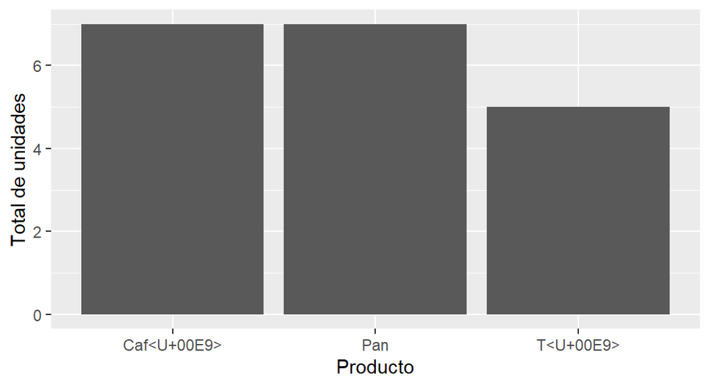

```r
library(ggplot2)
library(dplyr)
ventas_grafico <- data.frame(
  producto = c("Café", "Café", "Pan", "Pan", "Té", "Té"),
  unidades = c(2, 5, 1, 6, 2, 3),
  precio_crc = c(1500, 1500, 900, 900, 1200, 1200)
)
totales <- ventas_grafico |>
  group_by(producto) |>
  summarise(unidades = sum(unidades), .groups = "drop")
ggplot(totales, aes(producto, unidades)) + geom_col() +
  labs(x = "Producto", y = "Total de unidades")
```

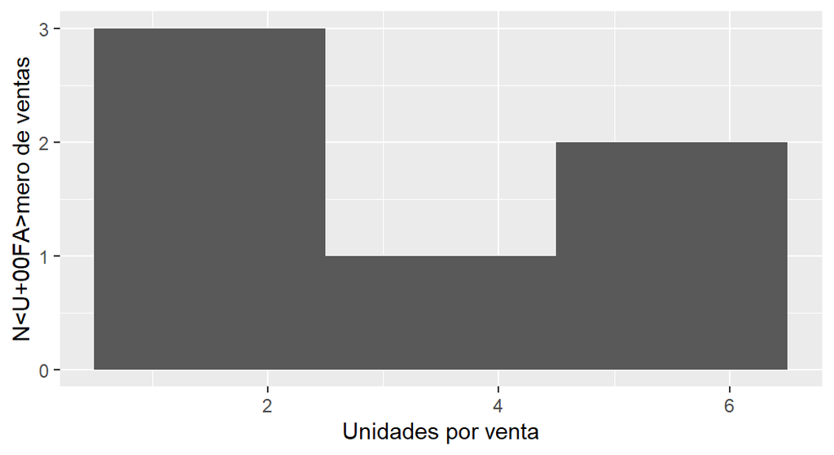

```r
ggplot(ventas_grafico, aes(unidades)) + geom_histogram(binwidth = 2, boundary = 0.5) +
  labs(x = "Unidades por venta", y = "Número de ventas")
```

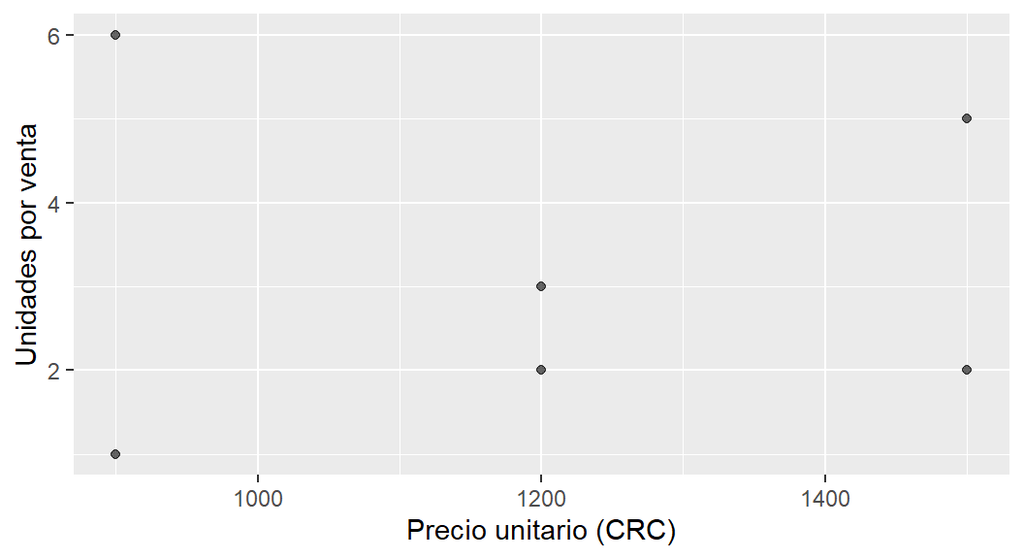

```r
ggplot(ventas_grafico, aes(precio_crc, unidades)) + geom_point(alpha = 0.6) +
  labs(x = "Precio unitario (CRC)", y = "Unidades por venta")
```

Para ampliar, compará el histograma con `binwidth = 1` y con `binwidth = 2`. [Documentación de geom_histogram()](https://ggplot2.tidyverse.org/reference/geom_histogram.html).

## Lección 6 · Unir tablas y comunicar resultados

El capítulo 5 combina dos data frames que comparten una columna. En este ejemplo la columna en común es `sede`. `left_join()` conserva las ventas y agrega el dato del catálogo. Compará cuántas filas hay antes y después, y fijate qué pasa con el dato de la sede ausente del catálogo. [Unir tablas por una clave](https://r4ds.hadley.nz/joins.html) · *Learning R* (Cotton, 2013, cap. 5) · [Documentación de left_join()](https://dplyr.tidyverse.org/reference/mutate-joins.html).

```r
ventas_sede <- data.frame(sede = c("Cartago", "Heredia", "Cartago"), unidades = c(4, 3, 6))
catalogo <- data.frame(sede = "Cartago", region = "Central")
tabla_final <- dplyr::left_join(ventas_sede, catalogo, by = "sede")
nrow(ventas_sede)
```

```
## [1] 3
```

```r
nrow(tabla_final)
```

```
## [1] 3
```

```r
knitr::kable(tabla_final, caption = "Ventas por sede y región")
```

Ventas por sede y región

| sede | unidades | region |
| --- | --- | --- |
| Cartago | 4 | Central |
| Heredia | 3 | NA |
| Cartago | 6 | Central |

Para ampliar, copiá el ejemplo a un bloque de R de tu propio `.Rmd`. Debajo del bloque, escribí una oración sobre la fila con región faltante. Generá el HTML con **Knit**. [Introducción oficial a R Markdown](https://rmarkdown.rstudio.com/articles_intro.html).

## Referencias

Cotton, R. (2013). *Learning R: A step-by-step function guide to data analysis*. O’Reilly Media.

Ihaka, R., & Gentleman, R. (1996). R: A language for data analysis and graphics. *Journal of Computational and Graphical Statistics, 5*(3), 299–314. `https://doi.org/10.1080/10618600.1996.10474713`

Logo de R © 2016 The R Foundation. [Archivo original](https://www.r-project.org/logo/) · [CC BY-SA 4.0](https://creativecommons.org/licenses/by-sa/4.0/). Se conserva la imagen original.